# quant_assignment_3

Rania Karamallah, MC Abbott, Alex Cardelle

11/8/2021

# Research Question

Is there a relationship between mode of transportation to travel to work and different health indicators? How do other demographic characteristics (eg. race and age) factor in, if at all?

# Prior Research

Riggs and Sethi (2020), in examining a quantified, indexed version of “walkability”, have determined that neighborhoods scoring high in this category do show increased multimodal/alternative transportation use (namely – walking, cycling, or transit). With more specificity, Watson et. al (2020) provide a national-level overview that confirms a strong link between high walkability scores and walking itself as a mode of commuting to work throughout the urban areas of the United States. Our research question seeks to confirm these findings through selected census and walkability study data.

# Data

We will be using the following data sets:

- United States American Community Survey (2019)
- Centers for Disease Control and Prevention: PLACES U.S. Chronic Disease Indicators (2020)
- United States Environmental Protection Agency: National Walkability Index (2021)

# Variables for Analysis

Continuous * Population Percentage with Current Mental Health Issues * Population Percentage with Obesity * Population Percentage with Current Asthma * Percentage of Mode of Transportation to Work * Walkability Index Score

Categorical * Majority White vs. Non-White * Majority Female vs. Not Female

## Sample Definition

Our research will focus on the scale of census tracts in Massachusetts, with a look at adult characteristics and behaviors aggregated to the level of census tracts.

## Load data

```r
library(tidyverse)
library(tidycensus)
library(readxl)
library(knitr)
library(sf)
library(gridExtra)
library(ggthemes)
library(ggspatial)
```

## Mode of Transportation

Source: American Community Survey (2019)

- Mode of Transportation

```r
acs_transport <- get_acs(geography = "tract",
                        year = 2019,
                        variables = c(transport_any = "B08301_001E",
                                      transport_walk = "B08301_019E",
                                      transport_car = "B08301_002E",
                                      transport_public = "B08301_010E",
                                      transport_bike = "B08301_018E",
                                      transport_taxi = "B08301_016E",
                                      transport_motorcycle = "B08301_017E",
                                      transport_other = "B08301_020E"),
                        state = "MA",
                        output = "wide",
                        geometry = FALSE) %>%
  mutate(pct_walk = transport_walk / transport_any) %>%
  mutate(pct_car = transport_car / transport_any) %>%
  mutate(pct_public = transport_public / transport_any) %>%
  mutate(pct_bike = transport_bike / transport_any) %>%
  mutate(pct_taxi = transport_taxi / transport_any) %>%
  mutate(pct_motorcycle = transport_motorcycle / transport_any) %>%
  mutate(pct_other = transport_other / transport_any)%>%
  select(GEOID, pct_walk, pct_car, pct_public, pct_bike, pct_taxi, pct_motorcycle, pct_other)
```

## Demographics

Source: American Community Survey (2019)

- Majority White vs. Non-White (categorical)
- Majority Female vs. Not Female (categorical)

```r
race_majority <- get_acs(geography = "tract",
                        year = 2019,
                        variables = c( total_pop = "B02001_001",
                                       white_pop = "B02001_002"),
                        state = "MA",
                        output = "wide",
                        geometry = FALSE) %>%
  mutate(white_majority = case_when(white_popE / total_popE >= .5 ~ "Majority White",
                          white_popE / total_popE < .5 ~ "Non-Majority White",
                          TRUE ~ "unknown")) %>%
  select(GEOID,white_majority)
sex_majority <- get_acs(geography = "tract",
                        year = 2019,
                        variables = c( total_pop = "B01001_001",
                                       female_pop = "B01001_026"),
                        state = "MA",
                        output = "wide",
                        geometry = FALSE) %>%
  mutate(female_majority = case_when(female_popE / total_popE >= .5 ~ "Female Majority",
                          female_popE / total_popE < .5 ~ "Non-Female Majority",
                          TRUE ~ "unknown")) %>%
  select(GEOID,female_majority)
```

## U.S. Chronic Disease Indicators

Source: United States Centers for Disease Control and Prevention: PLACES U.S. Chronic Disease Indicators

- Population Percentage with Current Mental Health Issues (continuous)
- Population Percentage with Obesity (continuous)
- Population Percentage with Current Asthma (continuous)

```r
Mental_Health <- read_csv('data/PLACES__Local_Data_for_Better_Health__Census_Tract_Data_2020_release.csv') %>%
  filter(Year == 2018) %>%
  filter(Short_Question_Text == "Mental Health") %>%
  filter(StateAbbr == "MA") %>%
  rename(GEOID = LocationID) %>%
  group_by(GEOID) %>%
  rename(pct_mental = Data_Value) %>%
  select(GEOID, pct_mental, Data_Value_Unit)
Asthma <- read_csv('data/PLACES__Local_Data_for_Better_Health__Census_Tract_Data_2020_release.csv') %>%
  filter(Year == 2018) %>%
  filter(Short_Question_Text == "Current Asthma") %>%
  filter(StateAbbr == "MA") %>%
  rename(GEOID = LocationID) %>%
  group_by(GEOID) %>%
  rename(pct_asthma = Data_Value) %>%
  select(GEOID, pct_asthma, Data_Value_Unit)
Obesity <- read_csv('data/PLACES__Local_Data_for_Better_Health__Census_Tract_Data_2020_release.csv') %>%
  filter(Year == 2018) %>%
  filter(Short_Question_Text == "Obesity") %>%
  filter(StateAbbr == "MA") %>%
  rename(GEOID = LocationID) %>%
  group_by(GEOID) %>%
  rename(pct_obesity = Data_Value) %>%
  select(GEOID, pct_obesity, Data_Value_Unit)
```

## Walkability

Source: United States Environmental Protection Agency: National Walkability Index

- Walkability Index Score

```r
Walkability <- st_read(dsn = "Natl_WI.gdb") %>%
  filter(STATEFP == "25") %>%
  select(GEOID10, NatWalkInd, TotPop) %>%
  mutate(tract = substr(GEOID10, 1, 11)) %>%
  st_set_geometry(NULL) %>%
  group_by(tract) %>%
  summarise(avg_walk_ind = weighted.mean(NatWalkInd, TotPop)) %>%
  rename(GEOID = tract)
```

# Assembling the datasets

```r
data <- left_join(acs_transport, Walkability) %>%
  left_join(Asthma) %>%
  left_join(Obesity) %>%
  left_join(Mental_Health) %>%
  left_join(race_majority) %>%
  left_join(sex_majority) %>%
  select(GEOID, avg_walk_ind, pct_walk, pct_car, pct_public, pct_bike, pct_taxi, pct_motorcycle, pct_other, pct_asthma, pct_mental, pct_obesity, white_majority, female_majority)

kable(head(data))
```

| GEOID | avg_walk_ind | pct_walk | pct_car | pct_public | pct_bike | pct_taxi | pct_motorcycle | pct_other | pct_asthma | pct_mental | pct_obesity | white_majority | female_majority |
| --- | --- | --- | --- | --- | --- | --- | --- | --- | --- | --- | --- | --- | --- |
| 25027731001 | 11.333333 | 0.0052493 | 0.9755031 | 0.0131234 | 0.0000000 | 0 | 0 | 0.0000000 | 10.1 | 14.0 | 30.8 | Majority White | Female Majority |
| 25027709501 | 7.333333 | 0.0000000 | 0.9022624 | 0.0199095 | 0.0000000 | 0 | 0 | 0.0000000 | 9.7 | 12.6 | 30.7 | Majority White | Female Majority |
| 25027709502 | 9.525729 | 0.0102145 | 0.9417773 | 0.0108955 | 0.0000000 | 0 | 0 | 0.0000000 | 10.0 | 12.7 | 30.0 | Majority White | Female Majority |
| 25027721101 | 3.833333 | 0.0078125 | 0.9101562 | 0.0029297 | 0.0029297 | 0 | 0 | 0.0146484 | 10.0 | 13.5 | 31.0 | Majority White | Female Majority |
| 25027721102 | 5.537969 | 0.0000000 | 0.9310201 | 0.0000000 | 0.0000000 | 0 | 0 | 0.0000000 | 9.6 | 12.4 | 29.6 | Majority White | Non-Female Majority |
| 25027731002 | 12.806539 | 0.0000000 | 0.9193947 | 0.0648548 | 0.0000000 | 0 | 0 | 0.0000000 | 11.0 | 16.1 | 35.4 | Majority White | Female Majority |

# Initial Analysis of Continuous Data

```r
asthma_t_test <- t.test(data$pct_asthma)
obesity_t_test <- t.test(data$pct_obesity)
mental_t_test <- t.test(data$pct_mental)
walkability_t_test <- t.test(data$avg_walk_ind)
mwalk_t_test <- t.test(data$pct_walk)
mcar_t_test <- t.test(data$pct_car)
mpublic_t_test <- t.test(data$pct_public)
mbike_t_test <- t.test(data$pct_bike)
mtaxi_t_test <- t.test(data$pct_taxi)
mmotorcycle_t_test <- t.test(data$pct_motorcycle)
mother_t_test <- t.test(data$pct_other)
```

```r
asthma_quartiles <- quantile(data$pct_asthma, na.rm = TRUE)
obesity_quartiles <- quantile(data$pct_obesity, na.rm = TRUE)
mental_quartiles <- quantile(data$pct_mental, na.rm = TRUE)

walk_quartiles <- quantile(data$pct_walk, na.rm = TRUE)
bike_quartiles <- quantile(data$pct_bike, na.rm = TRUE)
car_quartiles <- quantile(data$pct_car, na.rm = TRUE)
taxi_quartiles <- quantile(data$pct_taxi, na.rm = TRUE)
public_quartiles <- quantile(data$pct_public, na.rm = TRUE)
motorcycle_quartiles <- quantile(data$pct_motorcycle, na.rm = TRUE)
other_quartiles <- quantile(data$pct_other, na.rm = TRUE)
```

```r
asthma_st_dev <- sd(data$pct_asthma, na.rm = TRUE)
obesity_st_dev <- sd(data$pct_obesity, na.rm = TRUE)
mental_st_dev <- sd(data$pct_mental, na.rm = TRUE)

walk_st_dev <- sd(data$pct_walk, na.rm = TRUE)
bike_st_dev <- sd(data$pct_bike, na.rm = TRUE)
car_st_dev <- sd(data$pct_car, na.rm = TRUE)
taxi_st_dev <- sd(data$pct_taxi, na.rm = TRUE)
public_st_dev <- sd(data$pct_public, na.rm = TRUE)
motorcycle_st_dev <- sd(data$pct_motorcycle, na.rm = TRUE)
other_st_dev <- sd(data$pct_other, na.rm = TRUE)
```

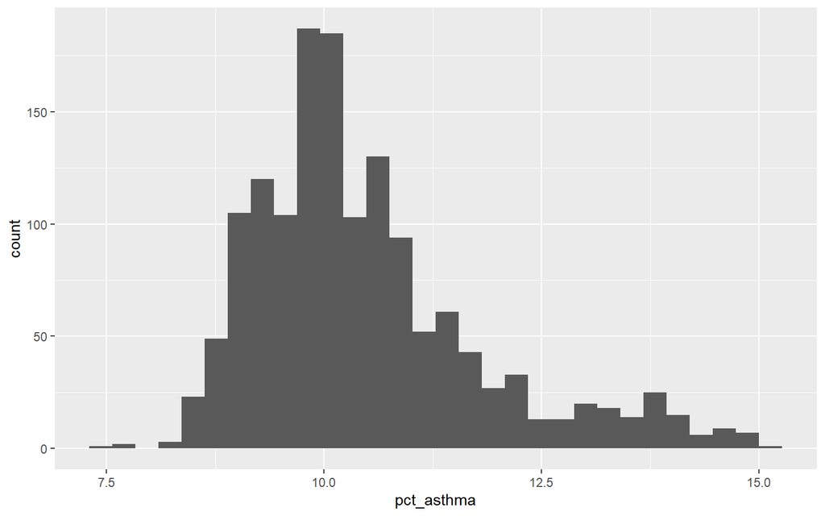

```r
asthma_hist <- ggplot(data) +
  geom_histogram(aes(x = pct_asthma),
                 bins = 30)

obesity_hist <- ggplot(data) +
  geom_histogram(aes(x = pct_obesity),
                 bins = 30) +
  scale_x_continuous(trans = "log")

mental_hist <- ggplot(data) +
  geom_histogram(aes(x = pct_mental),
                 bins = 30)

asthma_hist
```

```r
mode_summary <- tibble(
  Variable = c("Percentage of Workers Who Commute by Walking",
               "Percentage of Workers Who Commute by Bike",
               "Percentage of Workers Who Commute by Car",
               "Percentage of Workers Who Commute by Public Transit",
               "Percentage of Workers Who Commute by Taxi",
               "Percentage of Workers Who Commute by Motorcycle",
               "Percentage of Workers Who Commute by Other Means"),
  `Sample mean` = c((mwalk_t_test$estimate*100),
                    (mbike_t_test$estimate*100),
                    (mcar_t_test$estimate*100),
                    (mpublic_t_test$estimate*100),
                    (mtaxi_t_test$estimate*100),
                    (mmotorcycle_t_test$estimate*100),
                    (mother_t_test$estimate*100)),

  `Population mean (95% confidence) - low` =
    c((mwalk_t_test$conf.int[1]*100),
      (mbike_t_test$conf.int[1]*100),
      (mcar_t_test$conf.int[1]*100),
      (mpublic_t_test$conf.int[1]*100),
      (mtaxi_t_test$conf.int[1]*100),
      (mmotorcycle_t_test$conf.int[1]*100),
      (mother_t_test$conf.int[1]*100)),

  `Population mean (95% confidence) - high` =
    c((mwalk_t_test$conf.int[2]*100),
      (mbike_t_test$conf.int[2]*100),
      (mcar_t_test$conf.int[2]*100),
      (mpublic_t_test$conf.int[2]*100),
      (mtaxi_t_test$conf.int[2]*100),
      (mmotorcycle_t_test$conf.int[2]*100),
      (mother_t_test$conf.int[2])*100),

  Median = c((mwalk_t_test$conf.int[3]*100),
      (mbike_t_test$conf.int[3]*100),
      (mcar_t_test$conf.int[3]*100),
      (mpublic_t_test$conf.int[3]*100),
      (mtaxi_t_test$conf.int[3]*100),
      (mmotorcycle_t_test$conf.int[3]*100),
      (mother_t_test$conf.int[3]*100)),

  `Interquartile range` = c(((walk_quartiles[4] - walk_quartiles[2])*100),
                            ((bike_quartiles[4] - bike_quartiles[2])*100),
                            ((car_quartiles[4] - car_quartiles[2])*100),
                            ((public_quartiles[4] - public_quartiles[2])*100),
                            ((taxi_quartiles[4] - taxi_quartiles[2])*100),
                            ((motorcycle_quartiles[4] - motorcycle_quartiles[2])*100),
                            ((other_quartiles[4] - other_quartiles[2])*100)),
  `Standard deviation` = c((walk_st_dev*100), (bike_st_dev*100), (car_st_dev*100), (taxi_st_dev*100), (public_st_dev*100), (motorcycle_st_dev*100), (other_st_dev*100)))

kable(mode_summary, digits = 2)
```

| Variable | Sample mean | Population mean (95% confidence) - low | Population mean (95% confidence) - high | Median | Interquartile range | Standard deviation |
| --- | --- | --- | --- | --- | --- | --- |
| Percentage of Workers Who Commute by Walking | 5.58 | 5.07 | 6.09 | NA | 4.63 | 10.02 |
| Percentage of Workers Who Commute by Bike | 0.89 | 0.78 | 0.99 | NA | 0.72 | 2.04 |
| Percentage of Workers Who Commute by Car | 76.42 | 75.39 | 77.45 | NA | 20.37 | 20.05 |
| Percentage of Workers Who Commute by Public Transit | 10.50 | 9.83 | 11.18 | NA | 12.95 | 0.69 |
| Percentage of Workers Who Commute by Taxi | 0.29 | 0.25 | 0.32 | NA | 0.08 | 13.17 |
| Percentage of Workers Who Commute by Motorcycle | 0.08 | 0.06 | 0.10 | NA | 0.00 | 0.41 |
| Percentage of Workers Who Commute by Other Means | 1.03 | 0.95 | 1.12 | NA | 1.42 | 1.58 |

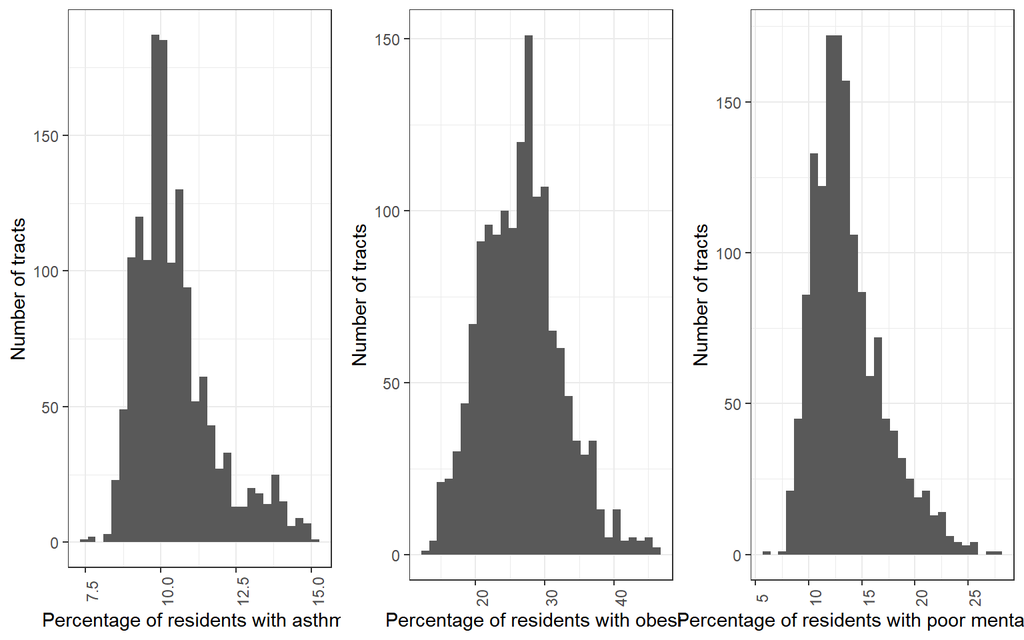

```r
pretty_asthma_hist <- asthma_hist +
  theme_bw() +
  scale_x_continuous(name = "Percentage of residents with asthma") +
  scale_y_continuous(name = "Number of tracts") +
  theme(axis.text.x = element_text(angle = 90))

pretty_obesity_hist <- obesity_hist +
  theme_bw() +
  scale_x_continuous(name = "Percentage of residents with obesity") +
  scale_y_continuous(name = "Number of tracts") +
  theme(axis.text.x = element_text(angle = 90))
pretty_mental_hist <- mental_hist +
  theme_bw() +
  scale_x_continuous(name = "Percentage of residents with poor mental health") +
  scale_y_continuous(name = "Number of tracts") +
  theme(axis.text.x = element_text(angle = 90))

grid.arrange(pretty_asthma_hist, pretty_obesity_hist, pretty_mental_hist,
             ncol = 3)
```

# Initial Analysis of Categorical Data

```r
pct_white <- t.test(data$white_majority == "Majority White")
pct_nonwhite <-  t.test(data$white_majority == "Non-Majority White")

pct_female <- t.test(data$female_majority == "Female Majority")
pct_notfemale <-  t.test(data$female_majority == "Non-Female Majority")
```

```r
cat_summary_race <- tibble(`Majority Race` =
                              c("White",
                                "Not White"),
                            `Sample proportion` =
                              c(pct_white$estimate * 100,
                                pct_nonwhite$estimate *100),
                            `95-percent confidence - low` =
                              c(pct_white$conf.int[1] * 100,
                                pct_nonwhite$conf.int[1] * 100),
                            `95-percent confidence - high` =
                              c(pct_white$conf.int[2] * 100,
                                pct_nonwhite$conf.int[2] * 100))

kable(cat_summary_race, digits = 2)
```

| Majority Race | Sample proportion | 95-percent confidence - low | 95-percent confidence - high |
| --- | --- | --- | --- |
| White | 89.51 | 87.95 | 91.08 |
| Not White | 9.54 | 8.04 | 11.04 |

```r
cat_summary_sex <- tibble(`Majority Sex` =
                              c("Female",
                                "Not Female"),
                            `Sample proportion` =
                              c(pct_female$estimate * 100,
                                pct_notfemale$estimate *100),
                            `95-percent confidence - low` =
                              c(pct_female$conf.int[1] * 100,
                                pct_notfemale$conf.int[1] * 100),
                            `95-percent confidence - high` =
                              c(pct_female$conf.int[2] * 100,
                                pct_notfemale$conf.int[2] * 100))

kable(cat_summary_sex, digits = 2)
```

| Majority Sex | Sample proportion | 95-percent confidence - low | 95-percent confidence - high |
| --- | --- | --- | --- |
| Female | 69.08 | 66.72 | 71.44 |
| Not Female | 29.97 | 27.63 | 32.31 |

# Assignment 3 - Regressions

In trying to understand the importance of walkability to health and commuting patterns, we ran a regression analysis for correlation using ‘cor.test’ and ‘age_model’, then plotted the data on a graph. Our dependent variable is “walkability” provided through a Massachusetts Census Tracts’ walkability score. Our independent variables are divided into two fields: health metrics and commuting choice. For health metrics, we are using the percent of the population afflicted with asthma, obesity, or mental health issues respectively. For commuting choice, we’re using the percent of the population that commutes via walking, biking, public transit, or car respectively.

### Walkability and Health Metrics

## Walkability and Asthma

```r
cor.test(~ avg_walk_ind + pct_asthma, data = data)
```

```
##
##  Pearson's product-moment correlation
##
## data:  avg_walk_ind and pct_asthma
## t = 11.883, df = 1461, p-value < 2.2e-16
## alternative hypothesis: true correlation is not equal to 0
## 95 percent confidence interval:
##  0.2494104 0.3428982
## sample estimates:
##       cor
## 0.2968655
```

```r
age_model <- lm(avg_walk_ind ~ pct_asthma, data = data)

summary(age_model)
```

```
##
## Call:
## lm(formula = avg_walk_ind ~ pct_asthma, data = data)
##
## Residuals:
##      Min       1Q   Median       3Q      Max
## -11.8997  -3.1243   0.3704   2.9462   8.7244
##
## Coefficients:
##             Estimate Std. Error t value Pr(>|t|)
## (Intercept)   2.4426     0.7741   3.155  0.00164 **
## pct_asthma    0.8722     0.0734  11.883  < 2e-16 ***
## ---
## Signif. codes:  0 '***' 0.001 '**' 0.01 '*' 0.05 '.' 0.1 ' ' 1
##
## Residual standard error: 3.723 on 1461 degrees of freedom
##   (15 observations deleted due to missingness)
## Multiple R-squared:  0.08813,    Adjusted R-squared:  0.0875
## F-statistic: 141.2 on 1 and 1461 DF,  p-value: < 2.2e-16
```

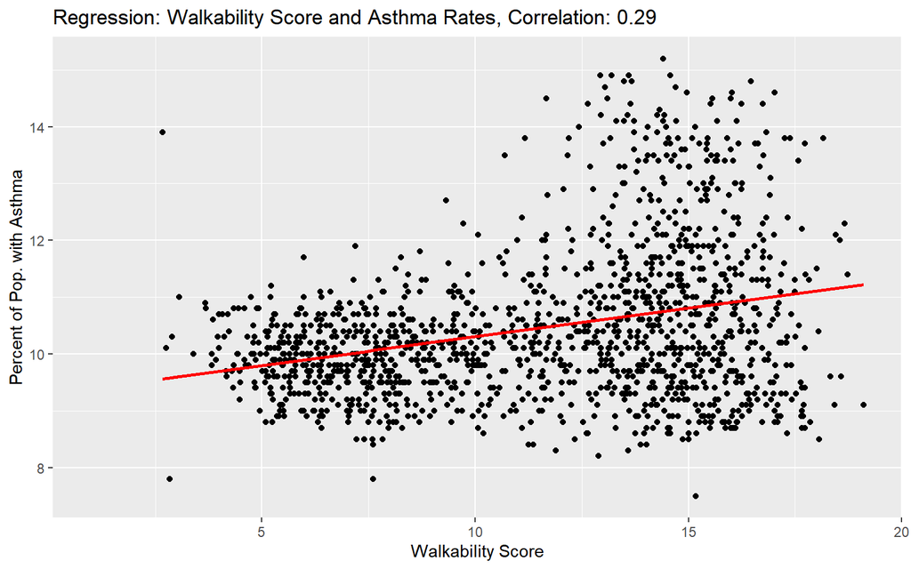

```r
ggplot(data) +
  geom_point(aes(x = avg_walk_ind, y = pct_asthma)) +
  geom_smooth(aes(x = avg_walk_ind, y = pct_asthma), color = 'red', method = 'lm', se = FALSE) +
  labs(x = "Walkability Score",
       y = "Percent of Pop. with Asthma",
       title = "Regression: Walkability Score and Asthma Rates, Correlation: 0.29")
```

For **asthma**, the 95-percent confidence interval for the correlation does not include zero - all values in the interval are positive. Additionally, this finding is supported by the regression, with an R-squared value of 0.08 and a p-value of less than 0.05. This means we can say with 95-percent confidence that higher asthma rates are associated with more walkable census tracts and that it is **statistically significant**.

## Walkability and Obesity

```r
cor.test(~ avg_walk_ind + pct_obesity, data = data)
```

```
##
##  Pearson's product-moment correlation
##
## data:  avg_walk_ind and pct_obesity
## t = -0.48809, df = 1461, p-value = 0.6256
## alternative hypothesis: true correlation is not equal to 0
## 95 percent confidence interval:
##  -0.06397625  0.03850640
## sample estimates:
##         cor
## -0.01276846
```

```r
age_model <- lm(avg_walk_ind ~ pct_obesity, data = data)

summary(age_model)
```

```
##
## Call:
## lm(formula = avg_walk_ind ~ pct_obesity, data = data)
##
## Residuals:
##     Min      1Q  Median      3Q     Max
## -8.8134 -3.5706  0.9706  3.2836  7.4787
##
## Coefficients:
##              Estimate Std. Error t value Pr(>|t|)
## (Intercept) 11.798894   0.484225  24.367   <2e-16 ***
## pct_obesity -0.008676   0.017775  -0.488    0.626
## ---
## Signif. codes:  0 '***' 0.001 '**' 0.01 '*' 0.05 '.' 0.1 ' ' 1
##
## Residual standard error: 3.899 on 1461 degrees of freedom
##   (15 observations deleted due to missingness)
## Multiple R-squared:  0.000163,   Adjusted R-squared:  -0.0005213
## F-statistic: 0.2382 on 1 and 1461 DF,  p-value: 0.6256
```

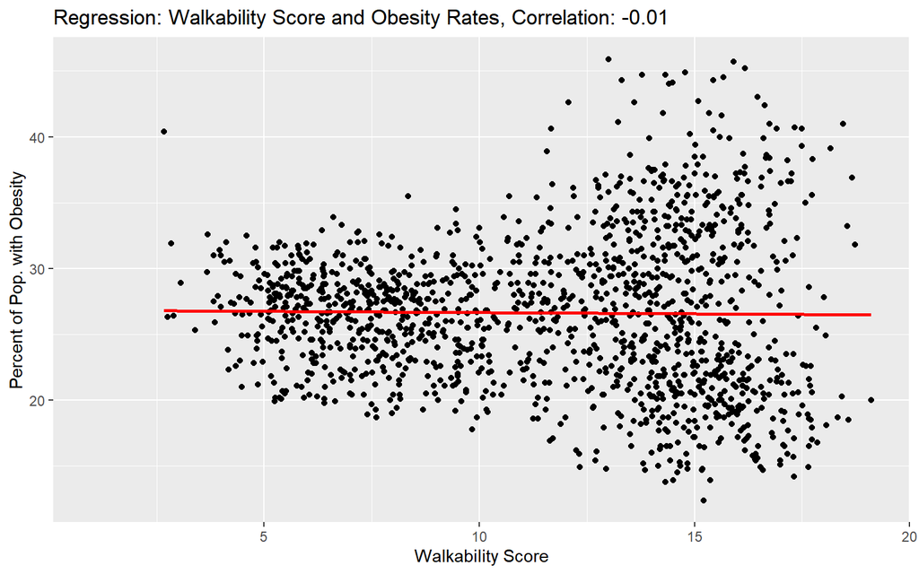

```r
ggplot(data) +
  geom_point(aes(x = avg_walk_ind, y = pct_obesity)) +
  geom_smooth(aes(x = avg_walk_ind, y = pct_obesity), color = 'red', method = 'lm', se = FALSE) +
  labs(x = "Walkability Score",
       y = "Percent of Pop. with Obesity",
       title = "Regression: Walkability Score and Obesity Rates, Correlation: -0.01")
```

For **obesity**, the 95-percent confidence interval for the correlation includes zero, meaning the direction of the correlation (positive or negative) is uncertain. Additionally, this finding is supported by the regression, with an R-squared value of -0.00052 and a p-value of 0.625. This means we cannot inform with with confidence whether obesity and walkable census tracts are correlated and that this finding’s significance is indeterminable with the present evidence.

## Walkability and Mental Health

```r
cor.test(~ avg_walk_ind + pct_mental, data = data)
```

```
##
##  Pearson's product-moment correlation
##
## data:  avg_walk_ind and pct_mental
## t = 13.737, df = 1461, p-value < 2.2e-16
## alternative hypothesis: true correlation is not equal to 0
## 95 percent confidence interval:
##  0.2920163 0.3828188
## sample estimates:
##       cor
## 0.3382045
```

```r
age_model <- lm(avg_walk_ind ~ pct_mental, data = data)

summary(age_model)
```

```
##
## Call:
## lm(formula = avg_walk_ind ~ pct_mental, data = data)
##
## Residuals:
##      Min       1Q   Median       3Q      Max
## -12.7242  -2.9927   0.3731   2.9256   8.3049
##
## Coefficients:
##             Estimate Std. Error t value Pr(>|t|)
## (Intercept)  6.08786    0.41030   14.84   <2e-16 ***
## pct_mental   0.39927    0.02907   13.74   <2e-16 ***
## ---
## Signif. codes:  0 '***' 0.001 '**' 0.01 '*' 0.05 '.' 0.1 ' ' 1
##
## Residual standard error: 3.669 on 1461 degrees of freedom
##   (15 observations deleted due to missingness)
## Multiple R-squared:  0.1144, Adjusted R-squared:  0.1138
## F-statistic: 188.7 on 1 and 1461 DF,  p-value: < 2.2e-16
```

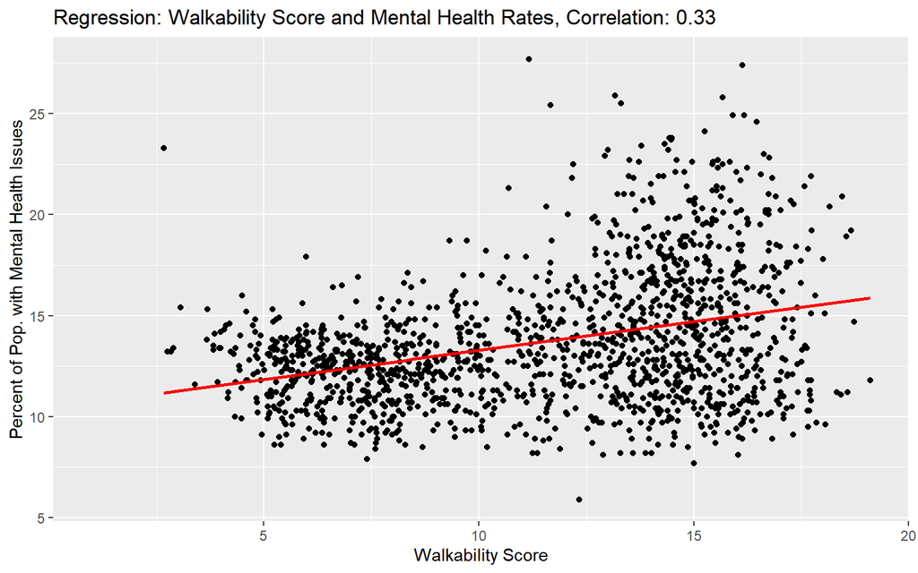

```r
ggplot(data) +
  geom_point(aes(x = avg_walk_ind, y = pct_mental)) +
  geom_smooth(aes(x = avg_walk_ind, y = pct_mental), color = 'red', method = 'lm', se = FALSE) +
  labs(x = "Walkability Score",
       y = "Percent of Pop. with Mental Health Issues",
       title = "Regression: Walkability Score and Mental Health Rates, Correlation: 0.33")
```

For **mental health**, the 95-percent confidence interval for the correlation does not include zero - all values in the interval are positive. Additionally, this finding is supported by the regression, with an R-squared value of 0.11 and a p-value of less than 0.05. This means we can say with 95-percent confidence that higher incidence of mental health issues are associated with more walkable census tracts and that this finding is **statistically significant**.

## Walkability and Commute Choice

## Walkability and Commuting by Walking

```r
cor.test(~ avg_walk_ind + pct_walk, data = data)
```

```
##
##  Pearson's product-moment correlation
##
## data:  avg_walk_ind and pct_walk
## t = 16.317, df = 1462, p-value < 2.2e-16
## alternative hypothesis: true correlation is not equal to 0
## 95 percent confidence interval:
##  0.3482749 0.4349887
## sample estimates:
##       cor
## 0.3925036
```

```r
age_model <- lm(avg_walk_ind ~ pct_walk, data = data)

summary(age_model)
```

```
##
## Call:
## lm(formula = avg_walk_ind ~ pct_walk, data = data)
##
## Residuals:
##      Min       1Q   Median       3Q      Max
## -10.8213  -3.1892   0.6462   3.0897   7.3097
##
## Coefficients:
##             Estimate Std. Error t value Pr(>|t|)
## (Intercept)  10.7073     0.1075   99.60   <2e-16 ***
## pct_walk     15.2938     0.9373   16.32   <2e-16 ***
## ---
## Signif. codes:  0 '***' 0.001 '**' 0.01 '*' 0.05 '.' 0.1 ' ' 1
##
## Residual standard error: 3.594 on 1462 degrees of freedom
##   (14 observations deleted due to missingness)
## Multiple R-squared:  0.1541, Adjusted R-squared:  0.1535
## F-statistic: 266.3 on 1 and 1462 DF,  p-value: < 2.2e-16
```

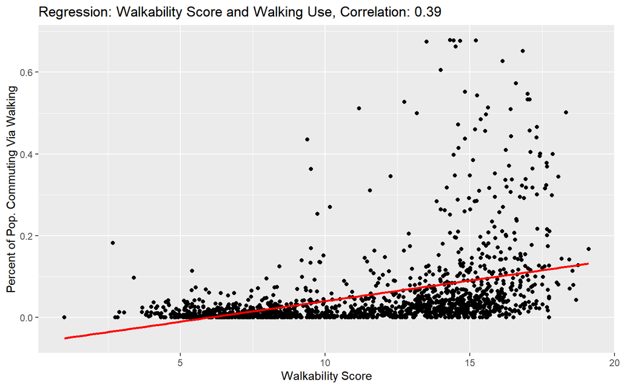

```r
ggplot(data) +
  geom_point(aes(x = avg_walk_ind, y = pct_walk)) +
  geom_smooth(aes(x = avg_walk_ind, y = pct_walk), color = 'red', method = 'lm', se = FALSE) +
  labs(x = "Walkability Score",
       y = "Percent of Pop. Commuting Via Walking",
       title = "Regression: Walkability Score and Walking Use, Correlation: 0.39")
```

For **commuting by walking**, the 95-percent confidence interval for the correlation does not include zero - all values in the interval are positive. Additionally, this finding is supported by the regression, with an R-squared value of 0.15 and a p-value of less than 0.05. This means we can say with 95-percent confidence that higher commuting rates by walking are associated with more walkable census tracts and that this finding is **statistically significant**.

## Walkability and Commuting by Biking

```r
cor.test(~ avg_walk_ind + pct_bike, data = data)
```

```
##
##  Pearson's product-moment correlation
##
## data:  avg_walk_ind and pct_bike
## t = 14.107, df = 1462, p-value < 2.2e-16
## alternative hypothesis: true correlation is not equal to 0
## 95 percent confidence interval:
##  0.3002402 0.3904558
## sample estimates:
##      cor
## 0.346148
```

```r
age_model <- lm(avg_walk_ind ~ pct_bike, data = data)

summary(age_model)
```

```
##
## Call:
## lm(formula = avg_walk_ind ~ pct_bike, data = data)
##
## Residuals:
##     Min      1Q  Median      3Q     Max
## -9.9704 -3.2022  0.5954  3.0827  7.7655
##
## Coefficients:
##             Estimate Std. Error t value Pr(>|t|)
## (Intercept)  10.9704     0.1045  104.94   <2e-16 ***
## pct_bike     66.4250     4.7085   14.11   <2e-16 ***
## ---
## Signif. codes:  0 '***' 0.001 '**' 0.01 '*' 0.05 '.' 0.1 ' ' 1
##
## Residual standard error: 3.666 on 1462 degrees of freedom
##   (14 observations deleted due to missingness)
## Multiple R-squared:  0.1198, Adjusted R-squared:  0.1192
## F-statistic:   199 on 1 and 1462 DF,  p-value: < 2.2e-16
```

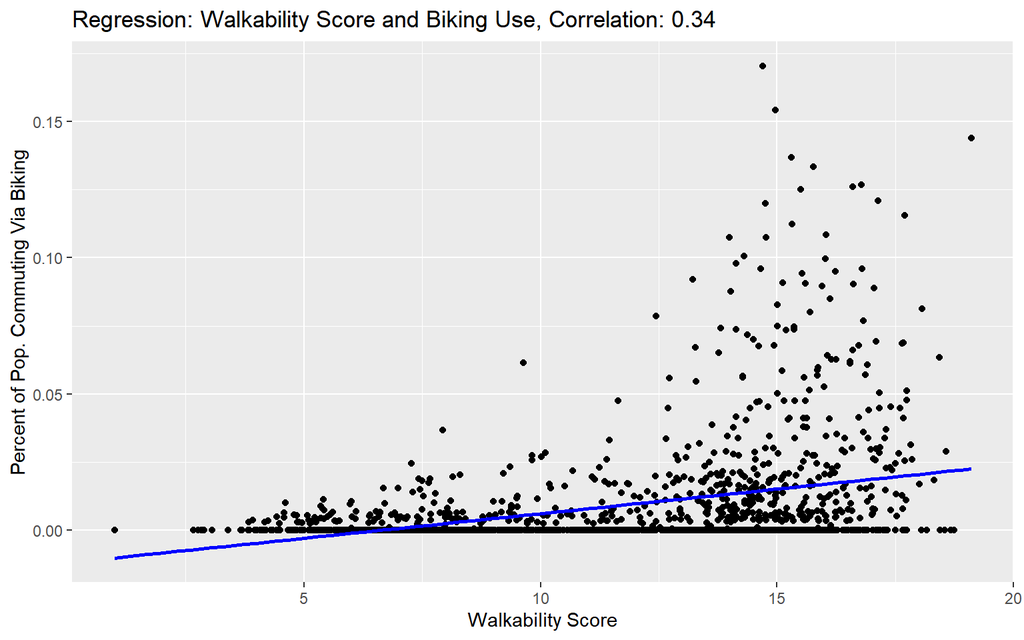

```r
ggplot(data) +
  geom_point(aes(x = avg_walk_ind, y = pct_bike)) +
  geom_smooth(aes(x = avg_walk_ind, y = pct_bike), color = 'blue', method = 'lm', se = FALSE) +
  labs(x = "Walkability Score",
       y = "Percent of Pop. Commuting Via Biking",
       title = "Regression: Walkability Score and Biking Use, Correlation: 0.34")
```

For **commuting by biking**, the 95-percent confidence interval for the correlation does not include zero - all values in the interval are positive. Additionally, this finding is supported by the regression, with an R-squared value of 0.11 and a p-value of less than 0.05. This means we can say with 95-percent confidence that higher commuting rates by biking are associated with more walkable census tracts and that this finding is **statistically significant**.

## Walkability and Commuting by Public Transit

```r
cor.test(~ avg_walk_ind + pct_public, data = data)
```

```
##
##  Pearson's product-moment correlation
##
## data:  avg_walk_ind and pct_public
## t = 19.814, df = 1462, p-value < 2.2e-16
## alternative hypothesis: true correlation is not equal to 0
## 95 percent confidence interval:
##  0.4187422 0.4995602
## sample estimates:
##       cor
## 0.4601037
```

```r
age_model <- lm(avg_walk_ind ~ pct_public, data = data)

summary(age_model)
```

```
##
## Call:
## lm(formula = avg_walk_ind ~ pct_public, data = data)
##
## Residuals:
##      Min       1Q   Median       3Q      Max
## -22.7747  -2.8021   0.2858   2.7100   8.1044
##
## Coefficients:
##             Estimate Std. Error t value Pr(>|t|)
## (Intercept)  10.1272     0.1160   87.31   <2e-16 ***
## pct_public   13.6476     0.6888   19.81   <2e-16 ***
## ---
## Signif. codes:  0 '***' 0.001 '**' 0.01 '*' 0.05 '.' 0.1 ' ' 1
##
## Residual standard error: 3.469 on 1462 degrees of freedom
##   (14 observations deleted due to missingness)
## Multiple R-squared:  0.2117, Adjusted R-squared:  0.2112
## F-statistic: 392.6 on 1 and 1462 DF,  p-value: < 2.2e-16
```

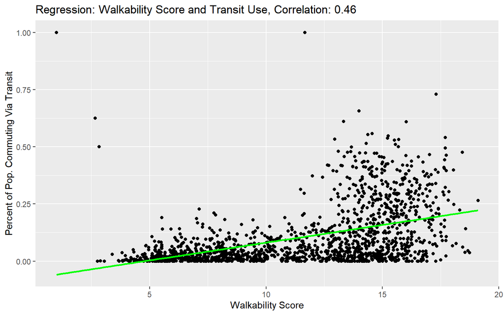

```r
ggplot(data) +
  geom_point(aes(x = avg_walk_ind, y = pct_public)) +
  geom_smooth(aes(x = avg_walk_ind, y = pct_public), color = 'green', method = 'lm', se = FALSE) +
  labs(x = "Walkability Score",
       y = "Percent of Pop. Commuting Via Transit",
       title = "Regression: Walkability Score and Transit Use, Correlation: 0.46")
```

For **commuting by transit**, the 95-percent confidence interval for the correlation does not include zero - all values in the interval are positive. Additionally, this finding is supported by the regression, with an R-squared value of 0.21 and a p-value of less than 0.05. This means we can say with 95-percent confidence that higher commuting rates by transit are associated with more walkable census tracts and that this finding is **statistically significant**.

## Walkability and Commuting by Car

```r
cor.test(~ avg_walk_ind + pct_car, data = data)
```

```
##
##  Pearson's product-moment correlation
##
## data:  avg_walk_ind and pct_car
## t = -23.1, df = 1462, p-value < 2.2e-16
## alternative hypothesis: true correlation is not equal to 0
## 95 percent confidence interval:
##  -0.5536691 -0.4785508
## sample estimates:
##       cor
## -0.517105
```

```r
age_model <- lm(avg_walk_ind ~ pct_car, data = data)

summary(age_model)
```

```
##
## Call:
## lm(formula = avg_walk_ind ~ pct_car, data = data)
##
## Residuals:
##      Min       1Q   Median       3Q      Max
## -18.2611  -2.7227   0.1955   2.6107   8.0268
##
## Coefficients:
##             Estimate Std. Error t value Pr(>|t|)
## (Intercept)  19.2611     0.3446   55.89   <2e-16 ***
## pct_car     -10.0765     0.4362  -23.10   <2e-16 ***
## ---
## Signif. codes:  0 '***' 0.001 '**' 0.01 '*' 0.05 '.' 0.1 ' ' 1
##
## Residual standard error: 3.344 on 1462 degrees of freedom
##   (14 observations deleted due to missingness)
## Multiple R-squared:  0.2674, Adjusted R-squared:  0.2669
## F-statistic: 533.6 on 1 and 1462 DF,  p-value: < 2.2e-16
```

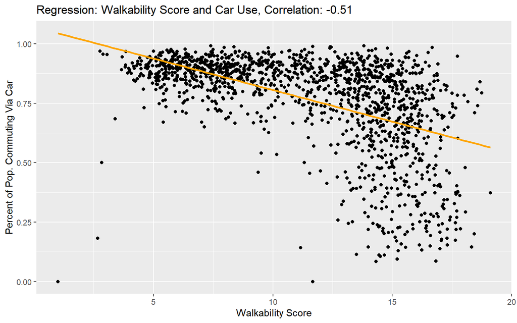

```r
ggplot(data) +
  geom_point(aes(x = avg_walk_ind, y = pct_car)) +
  geom_smooth(aes(x = avg_walk_ind, y = pct_car), color = 'orange', method = 'lm', se = FALSE) +
  labs(x = "Walkability Score",
       y = "Percent of Pop. Commuting Via Car",
       title = "Regression: Walkability Score and Car Use, Correlation: -0.51")
```

For **commuting by car**, the 95-percent confidence interval for the correlation does not include zero - all values in the interval are negative. Additionally, this finding is supported by the regression, with an R-squared value of 0.26 and a p-value of less than 0.05. This means we can say with 95-percent confidence that lower commuting rates by car are associated with more walkable census tracts and that this finding is **statistically significant**.

# Resources

Centers for Disease Control and Prevention, “PLACES: Local Data for Better Health, Census Tract Data 2020 release”. 2020. https://chronicdata.cdc.gov/500-Cities-Places/PLACES-Local-Data-for-Better-Health-Census-Tract-D/cwsq-ngmh

United States Census Bureau. American Community Survey, 5-year estimates. 2019.

Watson et al., “Associations between the National Walkability Index and walking among US Adults - National Health Interview Survey, 2015”. 2020. https://pubmed.ncbi.nlm.nih.gov/32389677/

Riggs, William Warren and Suresh Andrew Sethi, “Multimodal travel behaviour, walkability indices, and social mobility: how neighbourhood walkability, income and household characteristics guide walking, biking & transit decisions”. 2020. https://www.researchgate.net/publication/344647424_Multimodal_travel_behaviour_walkability_indices_and_social_mobility_how_neighbourhood_walkability_income_and_household_characteristics_guide_walking_biking_transit_decisions